# Querying genes across specificity matrices

Regina H. Reynolds

# 1 Aim

- Quick tutorial of `MarkerGenes::query_gene_ctd()` function, which allows users to query a gene or several genes within several specificity matrices.

# 2 Mock example

- We will use the human gene, SNCA, as our mock example.
- We are only interested in SNCA's specificity in human datasets, thus we will query the following datasets:

```r
readxl::read_excel(path = here::here("metadata", "dataset_metadata.xlsx"), sheet = "Data") %>%
  dplyr::filter(species == "human", data_type == "SI_matrix") %>%
  DT::datatable(rownames = FALSE,
                options = list(scrollX = TRUE),
                class = 'white-space: nowrap')
```

| resource_name | first_author | publication_year | publication_link | species | tissue_region | model | single_or_bulk | number_of_samples_donors | number_of_cells | number_of_celltypes_identified_level1 | number_of_celltypes_identified_level2 | download_link | original_filename | data_type |
| --- | --- | --- | --- | --- | --- | --- | --- | --- | --- | --- | --- | --- | --- | --- |
| Habib2017_DroNc_Human | Habib | 2017 | https://www.nature.com/articles/nmeth.4407 | human | hippocampus;pre_frontal_cortex | control;post_mortem | single_nuclei | 5 | 19550 | 10 | 15 | https://github.com/NathanSkene/MAGMA_Celltyping/tree/master/data | ctd_DRONC_human.rda | SI_matrix |
| AIBS2018_MTG | Unpublished | NA | NA | human | middle_temporal_gyrus | control;post_mortem | single_nuclei | 8 | 15928 | 7 | 75 | https://portal.brain-map.org/atlases-and-data/rnaseq/human-mtg-smart-seq | human_MTG_gene_expression_matrices_2018-06-14.zip | SI_matrix |
| Agarwal2020_SNIG | Agarwal | 2020 | https://www.nature.com/articles/s41467-020-17876-0 | human | substantia_nigra | control;post_mortem | single_nuclei | 5 | 6105 | 7 | 10 | https://www.ncbi.nlm.nih.gov/geo/query/acc.cgi?acc=GSE140231 | GSE140231_RAW.tar | SI_matrix |
| Agarwal2020_CRTX | Agarwal | 2020 | https://www.nature.com/articles/s41467-020-17876-0 | human | cortex | control;post_mortem | single_nuclei | 5 | 12015 | 6 | 23 | https://www.ncbi.nlm.nih.gov/geo/query/acc.cgi?acc=GSE140231 | GSE140231_RAW.tar | SI_matrix |
| Lake2018_FrontalCortexOnly | Lake | 2018 | https://www.ncbi.nlm.nih.gov/pubmed/29227469 | human | frontal_cortex_BA6_BA10 | control;post_mortem | single_nuclei | 4 | 10319 | 8 | 24 | https://github.com/NathanSkene/MAGMA_Celltyping | ctd_BlueLake2018_FrontalCortexOnly.Rda | SI_matrix |
| Lake2018_VisualCortexOnly | Lake | 2018 | https://www.ncbi.nlm.nih.gov/pubmed/29227469 | human | visual_cortex_BA17 | control;post_mortem | single_nuclei | 5 | 19368 | 8 | 28 | https://github.com/NathanSkene/MAGMA_Celltyping | ctd_BlueLake2018_VisualCortexOnly.Rda | SI_matrix |

- As AIBS2018_MTG is the more up to data of the AIBS datasets, we will use this, together with Habib2017_DroNc_Human. In addition, we will be using some of our own in-house single-nuclear RNA-sequencing from the anterior cingulate cortex of control individuals (n = 7).
  - It is worth noting that there are key differences in methodology between the AIBS dataset and the two remaining (i.e. Habib and our own in-house snRNA). While both sequence single nuclei, AIBS uses the SMART-Seq v4 kit, which permits sequence of full-length transcripts, while Habib and our in-house data use a 3'-tagging technology i.e. not full-length transcripts sequenced. This may have an impact on gene specificity.
- Let's go ahead and load in these specificity matrices and query them for SNCA specificity.
- As we are only interested in SNCA's specificity in overarching cell types, let's limit this search to level 1 cell types.

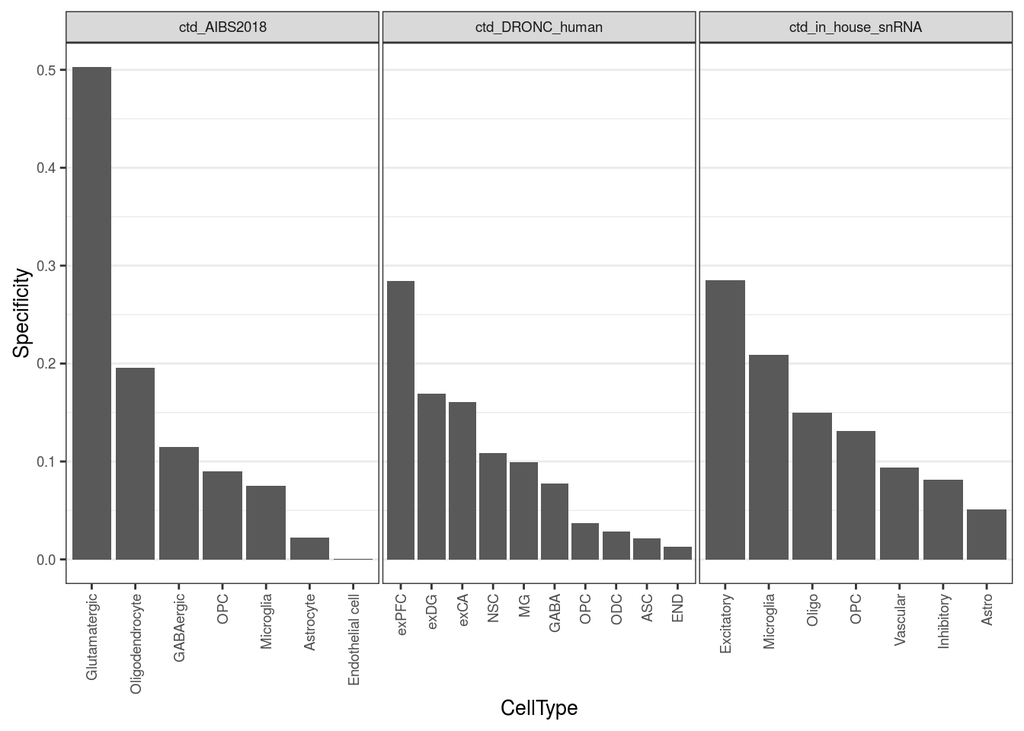

**Figure**: Plot of SNCA specificity value across three single-nuclear RNA-seq datasets. exPFC=glutamatergic neurons from the PFC, exCA1/3=pyramidal neurons from the Hip CA region, GABA=GABAergic interneurons, exDG=granule neurons from the Hip dentate gyrus region, ASC=astrocytes, NSC=neuronal stem cells, MG=microglia, ODC=oligodendrocytes, OPC=oligodendrocyte precursor cells, NSC=neuronal stem cells, SMC=smooth muscle cells, END= endothelial cells.

```r
# Load specificity matrices
load("../specificity_matrices/AIBS2018_MTG.rda")
load("../specificity_matrices/Habib2017_DroNc_Human.rda")
ctd_in_house_snRNA <- readRDS("/home/rreynolds/projects/Aim2_PDsequencing_wd/results/snRNA/specificity_matrices/2020_March/ctd_Control.rds")
load("../specificity_matrices/Agarwal2020_SNIG.rda")

specificity <-
  MarkerGenes::query_gene_ctd(genes = c("SNCA"),
                              ctd_AIBS2018, ctd_DRONC_human, ctd_in_house_snRNA,
                              celltypeLevel = 1,
                              median_included = F,
                              genelistSpecies = "human",
                              ctdSpecies = "human")

# Plot
specificity %>%
  ggplot(aes(x = MarkerGenes::reorder_within(x = CellType,
                                             by = Specificity,
                                             within = Study,
                                             fun = median,
                                             desc = T),
             y = Specificity)) +
  geom_col() +
  MarkerGenes::scale_x_reordered() +
  facet_wrap(~ Study, scales = "free_x") +
  labs(x = "CellType") +
  theme_rhr
```

- For all three datasets, SNCA appears to have its highest specificity in some form of excitatory neuron.
- Thereafter, the ordering of cell types is a little more ambiguous, and changes slightly dependent on the dataset.